# CausalML Lecture 2 — Demo

**Drew Dimmery**

We keep the randomised experiment from Week 1 and ask this week's question: should we adjust for covariates? Four results to establish:

> 1. Freedman's bias is real and $O(1/N)$, and a closed form predicts it.
> 2. Un-interacted adjustment can *raise* the variance. Lin's interacted version cannot.
> 3. Unbiasedness survives any adjustment function, as long as the assignment cannot see it.
> 4. When $p$ is large, arm-wise OLS breaks and the Lasso does not.

## Setup Instructions

This notebook runs in the shared `lecture-slides` environment, managed with [uv](https://docs.astral.sh/uv/).

1. **Install uv** (if not already installed):

   ```
   curl -LsSf https://astral.sh/uv/install.sh | sh
   ```

2. **Navigate to the repository root** (the directory holding `pyproject.toml`) and sync:

   ```
   uv sync
   ```

3. **Register the Jupyter kernel** (once per machine):

   ```
   make kernel
   ```

4. **Start Jupyter** and pick the `cml26-lectures` kernel:

   ```
   uv run jupyter lab
   ```

`make notebook 2` runs this notebook end to end and exports it to HTML. It takes about five minutes, most of it Study 4, which fits a cross-validated Lasso 1,200 times.

The environment, for the record:

```python
with open('../pyproject.toml', 'r') as f:
    print(f.read())
```

```
[project]
name = "lecture-slides"
version = "0.1.0"
description = "Causal Machine Learning lecture slides and demos"
requires-python = ">=3.12"
dependencies = [
    "ipykernel>=6.29",
    "jupyter>=1.1",
    "matplotlib>=3.9",
    "numpy>=2.0",
    "pandas>=2.0",
    "plotnine>=0.14",
    "polars>=1.0",
    "pyarrow>=17",
    "pyyaml>=6.0",
    "scikit-learn>=1.5",
]

[dependency-groups]
dev = [
    "pytest>=8.0",
    "ruff>=0.8",
    "statsmodels>=0.14",
]

[build-system]
requires = ["setuptools>=75"]
build-backend = "setuptools.build_meta"

[tool.setuptools.packages.find]
where = ["src"]

[tool.setuptools.package-data]
cml26 = ["*.css"]

[tool.ruff]
src = ["src"]

[tool.ruff.lint]
select = ["E", "F", "I", "UP"]
```

## Simulation Plan

Write the plan before the code, using the **ADEMP** structure from [Morris, White and Crowther (2019)](https://doi.org/10.1002/sim.8086), as in Week 1.

### Aims

Work out when covariate adjustment helps, when it hurts, and what it costs. Four questions, one per paper on the slides:

1. **Freedman.** The un-interacted regression is biased. How big is the bias, and does the $1/N$ formula from the proof sketch describe it?
2. **Freedman / Lin.** Adjustment is meant to improve precision. Can it make precision worse, and does interacting fix that?
3. **Aronow and Middleton.** Unbiasedness needs the adjustment to be fixed, not correct. What happens when we break that, and by how much?
4. **Bloniarz et al.** Lin's fix inverts an arm-level $X'X$. What happens when $p$ gets close to $N_a$, and does the Lasso fix it?

### Data-generating mechanism

Studies 1–3 reuse the Week 1 DGP unchanged, so everything we established there still applies:

$$X_i \sim \text{Uniform}(0, 5), \qquad Y_i(0) = 10 - e^{X_i/3} + \varepsilon_{i0}, \qquad Y_i(1) = 10 - e^{X_i/5} + \varepsilon_{i1},$$

with $\varepsilon_{ia} \sim \mathcal{N}(0, 0.2^2)$ drawn independently for the two potential outcomes. Two features matter this week:

- $\mathbb{E}[Y \mid X]$ is **nonlinear**, so a linear adjustment is misspecified by construction.
- $\tau_i = e^{X_i/3} - e^{X_i/5} + (\varepsilon_{i1} - \varepsilon_{i0})$ is **increasing in $X$**, so $X$ predicts effect heterogeneity. That is what the slides need for adjustment to hurt ($c_{\text{het}} \neq 0$), and what drives Freedman's bias ($\tau_i - \tau$).

Study 4 needs many covariates, so it uses a sparse linear DGP of its own, defined where it is used.

### Estimand

The average treatment effect throughout. Every estimator below targets it under the same design; they differ only in how the adjustment is fit. Which *average* — the SATE of the realised sample or the PATE of the population — depends on what we hold fixed, as in Week 1.

### Methods

Three estimators for one covariate, all of them the treatment coefficient of a regression:

| Estimator | Regression | Standard error |
| --- | --- | --- |
| Unadjusted | `y ~ a` | Neyman |
| Un-interacted (Freedman) | `y ~ a + x` | HC2 |
| Interacted (Lin) | `y ~ a + xc + a:xc` | HC2 |

`xc` is the covariate centred at its grand mean, and `a:xc` their interaction. Study 3 adds the Horvitz–Thompson and generalized difference estimators; Study 4 swaps the arm-wise fit from OLS to the Lasso.

### Performance

Bias with its Monte Carlo error, the variance of the estimates, the average estimated standard error, and coverage of the nominal 95% interval. Where the slides give a closed form for one of these, we compute it too and plot it against the simulated value. Agreement between a formula and a simulation is worth more than either alone.

## Simulation

### Set up the environment

The tools, same as Week 1:

- [`numpy`](https://numpy.org/doc/stable/) for numerical computation.
- [`polars`](https://docs.pola.rs/) for dataframes.
- [`plotnine`](https://plotnine.readthedocs.io/), which is `ggplot2` for Python.
- `cml26`, the class package in `src/cml26/`. `apply_style()` sets the house theme, `COLORS` is the palette, and `cml26.estimators` holds the estimators we compare — see below.
- [`scikit-learn`](https://scikit-learn.org/) arrives in Study 4, for the Lasso.

Two habits from Week 1: seed through a single generator and pass it explicitly; never estimate one replication at a time when the whole simulation fits in an array.

```python
%matplotlib inline

import numpy as np
import polars as pl
import plotnine as p9

from cml26 import (
    COLORS,
    apply_style,
    arm_wise_adjust,
    complete_randomisation,
    diff_in_means,
    freedman_adjust,
    lin_adjust,
    ols_hc2,
    scale_color_cml,
)

apply_style()
pl.Config.set_tbl_cols(12)
pl.Config.set_tbl_rows(30)

# One generator, passed explicitly to everything below.
rng = np.random.default_rng(20260908)

Z95 = 1.959964  # the 97.5th percentile of the standard normal, not 1.96
```

### Data-generating functions

Straight from Week 1. `draw_potential_outcomes` takes a shape rather than a length, so we can draw a grid of samples — one row per replication — in a single call. The assignment mechanism, `complete_randomisation`, comes from the class package along with the estimators.

```python
def draw_potential_outcomes(shape, rng):
    """The Week 1 DGP. `shape` may be an int or a tuple, so we can draw grids of samples."""
    x = rng.uniform(0, 5, size=shape)
    y0 = 10 - np.exp(x / 3) + rng.normal(0, 0.2, size=shape)
    y1 = 10 - np.exp(x / 5) + rng.normal(0, 0.2, size=shape)
    return x, y0, y1


def generate_population(n_pop, rng):
    """Draw a fixed population of potential outcomes."""
    x, y0, y1 = draw_potential_outcomes(n_pop, rng)
    return pl.DataFrame({"x": x, "y0": y0, "y1": y1})


def srswor(n, population, rng):
    """Simple random sample of size n, without replacement."""
    return population[rng.choice(population.height, size=n, replace=False)]


# The superpopulation ATE, known exactly because we wrote the DGP:
ATE = 0.6 * (np.exp(5 / 3) - 1) - (np.exp(1) - 1)
print(f"Superpopulation ATE, E[tau_i]: {ATE:0.4f}")
```

```
Superpopulation ATE, E[tau_i]: 0.8584
```

## Three estimators

All three live in the class package, at `src/cml26/estimators.py`, and take `(reps, n)` arrays, returning one estimate and one standard error per row. That shape is for speed: the studies below need up to $10^5$ replications to resolve effects of order $1/N$, which a Python loop over replications could not deliver.

### Unadjusted

Week 1's difference in means, with Neyman's variance estimator $\hat{V} = s_1^2/N_1 + s_0^2/N_0$.

### Un-interacted: the estimator Freedman objects to

The coefficient on $A$ in $Y \sim 1 + A + X$, computed as the proof sketch does — by Frisch–Waugh–Lovell on the two centred regressors, inverting the $2 \times 2$ centred cross-product matrix of $(A, X)$ and reading off the first coefficient.

The standard error is **HC2**, which for a regressor matrix $\mathbf{Z}$ replaces the classical $\sigma^2(\mathbf{Z}'\mathbf{Z})^{-1}$ with

$$(\mathbf{Z}'\mathbf{Z})^{-1}\Big[\textstyle\sum_i \frac{e_i^2}{1 - h_{ii}} \mathbf{z}_i\mathbf{z}_i'\Big](\mathbf{Z}'\mathbf{Z})^{-1},$$

where $h_{ii}$ is unit $i$'s leverage. Dividing by $1 - h_{ii}$ separates HC2 from HC0. It undoes the shrinkage of squared residuals at high-leverage points, which is why HC2 rather than HC0 matches Neyman's estimator.

### Interacted: Lin's estimator

$Y \sim 1 + A + \tilde{X} + A\tilde{X}$ with $\tilde{X} = X - \bar{X}$. Those four columns span the same space as two separate arm-wise regressions, so we fit it the way the slides write it:

$$\hat{\tau}_{\text{Lin}} = \big[\bar{Y}_1 - (\bar{X}_1 - \bar{X})'\hat{\beta}^{(1)}\big] - \big[\bar{Y}_0 - (\bar{X}_0 - \bar{X})'\hat{\beta}^{(0)}\big].$$

Each arm's contribution is that arm's fitted line **evaluated at the grand mean $\bar{X}$**, and the estimate is the vertical gap between the two lines there. In code, one arm at a time:

```
for arm, sign in ((a, 1.0), (~a, -1.0)):
    xa, ya = x[arm].mean(), y[arm].mean()
    dx, dy = x[arm] - xa, y[arm] - ya
    b = (dx * dy).sum() / (dx * dx).sum()       # this arm's slope
    tau_hat += sign * (ya - b * (xa - x.mean()))  # its line, read at the grand mean
```

This is the form Study 4 generalises, and it makes the standard error transparent. The slides say

$$\text{Var}(\hat{\tau}) \approx \frac{S_1^2}{N_1} + \frac{S_0^2}{N_0},$$

*Neyman's estimator applied to residuals* — the arm-wise fit turns $Y$ into $e$ and nothing else changes. `lin_adjust` implements the exact HC2 version, which weights each arm's residuals by $g_i = 1/N_a + (X_i - \bar{X}_a)(\bar{X} - \bar{X}_a)/S_{xx,a}$ rather than by $1/N_a$ alone. The extra piece is the cost of evaluating the line at $\bar{X}$ instead of at $\bar{X}_a$; since $\bar{X} - \bar{X}_a = O(N^{-1/2})$ it is an $O(1/N)$ correction, which is what the slide's $\approx$ covers.

### Why you can trust the algebra

All three are hand-rolled algebra rather than calls to a regression library, and we use them to detect effects of order $0.005$. So they are tested. `tests/test_estimators.py` pins each one against `statsmodels` — an independent implementation, on the same design matrix — at a relative tolerance of $10^{-12}$, along with the claims that Neyman's variance *is* HC2 of a regression on treatment alone, that Study 4's pluggable `arm_wise_adjust` reduces to `lin_adjust` when the fit is OLS, and that the $\approx$ above shrinks like $1/N$.

```
uv run pytest        # 26 passed
```

Re-run that if you change an estimator. Nothing below re-derives it.

```python
ESTIMATORS = {
    "unadjusted": diff_in_means,
    "un-interacted": freedman_adjust,
    "Lin": lin_adjust,
}
```

### One driver for every study

Each study randomises `reps` times and applies every estimator, in blocks so the `(reps, n)` arrays stay a sane size in memory.

The shape of the potential outcomes sets the design of the study:

- **1-d** `x, y0, y1`: one fixed sample, re-randomised `reps` times. Only the assignment is random, so this isolates design-based behaviour relative to that sample's SATE.
- **2-d** with `reps` rows: a fresh sample per replication. Sampling and assignment are both random, and the target is the population ATE.

```python
def run_experiments(x, y0, y1, n1, reps, rng, cell_budget=8_000_000):
    """Randomise `reps` times and apply every estimator. Returns one row per (replication, method)."""
    n = np.shape(x)[-1]
    fixed_sample = np.ndim(x) == 1
    block = max(1, cell_budget // n)

    chunks = []
    start = 0
    while start < reps:
        r = min(block, reps - start)
        rows = slice(start, start + r)
        xb = x if fixed_sample else x[rows]
        y0b, y1b = (y0, y1) if fixed_sample else (y0[rows], y1[rows])

        a = complete_randomisation(r, n, n1, rng)
        y = np.where(a, y1b, y0b)
        x_rep = np.broadcast_to(np.atleast_2d(xb), (r, n))
        sate = np.broadcast_to((y1b - y0b).mean(-1), (r,))

        for method, estimator in ESTIMATORS.items():
            tau_hat, se_hat = estimator(x_rep, y, a)
            chunks.append(
                pl.DataFrame({
                    "rep": np.arange(start, start + r),
                    "method": np.full(r, method),
                    "tau_hat": tau_hat,
                    "se_hat": se_hat,
                    "sate": sate,
                })
            )
        start += r
    return pl.concat(chunks)


METHOD_ORDER = list(ESTIMATORS)


def by_method(df, *aggs, **named):
    """Aggregate a run, keeping the methods in a fixed order."""
    return (
        df.group_by("method")
        .agg(*aggs, **named)
        .with_columns(_o=pl.col("method").replace_strict(METHOD_ORDER, list(range(len(METHOD_ORDER)))))
        .sort("_o")
        .drop("_o")
    )
```

## Exploration: one population, one sample, one experiment

Before any simulation, look at what the three estimators do to a single dataset. Population and sample sizes are parameters. The population is much larger than the sample, so the finite-population correction stays negligible and the Week 1 algebra applies unchanged.

```python
N_POPULATION = 2_000
N_SAMPLE = 40
N_TREATED = 20

P = generate_population(N_POPULATION, rng)
pate = (P["y1"] - P["y0"]).mean()
print(f"PATE:                {pate:0.4f}")
print(f"Superpopulation ATE: {ATE:0.4f}")
```

```
PATE:                0.8701
Superpopulation ATE: 0.8584
```

### The covariate predicts the level *and* the effect

The slides ask two separate questions about a covariate. Does $X$ predict the **level** of the outcome, $c_{\text{lvl}}$? Does it predict the **effect**, $c_{\text{het}}$? Here both are nonzero: $c_{\text{lvl}} \neq 0$ is why adjustment can help, and $c_{\text{het}} \neq 0$ is why it can hurt.

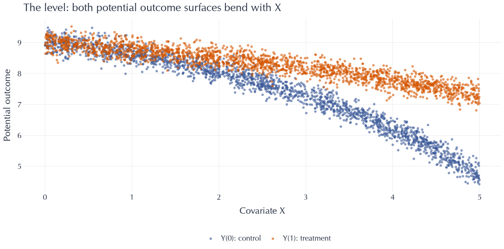

```python
P_long = P.unpivot(
    on=["y0", "y1"], index="x", variable_name="po", value_name="value"
).with_columns(
    surface=pl.col("po").replace_strict({"y0": "Y(0): control", "y1": "Y(1): treatment"})
)

(
    p9.ggplot(P_long, p9.aes(x="x", y="value", color="surface"))
    + p9.geom_point(size=0.8, alpha=0.5)
    + scale_color_cml()
    + p9.labs(
        title="The level: both potential outcome surfaces bend with X",
        x="Covariate X",
        y="Potential outcome",
        color="",
    )
)
```

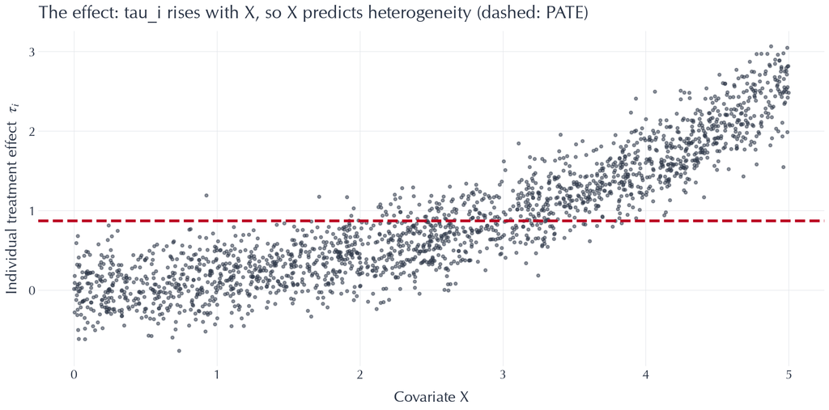

```python
(
    p9.ggplot(P, p9.aes(x="x", y="y1 - y0"))
    + p9.geom_point(size=0.8, alpha=0.5, color=COLORS["data"])
    + p9.geom_hline(yintercept=pate, color=COLORS["truth"], size=1.2, linetype="dashed")
    + p9.labs(
        title="The effect: tau_i rises with X, so X predicts heterogeneity (dashed: PATE)",
        x="Covariate X",
        y=r"Individual treatment effect  $\tau_i$",
    )
)
```

### One experiment, three estimates

Draw a sample, randomise once, and apply all three estimators.

```python
S = srswor(N_SAMPLE, P, rng)
sate = (S["y1"] - S["y0"]).mean()

x_S, y0_S, y1_S = S["x"].to_numpy(), S["y0"].to_numpy(), S["y1"].to_numpy()
a_one = complete_randomisation(1, N_SAMPLE, N_TREATED, rng)
y_one = np.where(a_one, y1_S, y0_S)

print(f"SATE of this sample: {sate:0.4f}")
print(f"PATE:                {pate:0.4f}\n")
print(f"{'method':<15} {'estimate':>9} {'SE':>8}   {'95% interval':>18}  SATE  PATE")
for method, estimator in ESTIMATORS.items():
    tau_hat, se_hat = estimator(x_S[None, :], y_one, a_one)
    lo, hi = tau_hat[0] - Z95 * se_hat[0], tau_hat[0] + Z95 * se_hat[0]
    print(
        f"{method:<15} {tau_hat[0]:>9.4f} {se_hat[0]:>8.4f}   [{lo:>7.4f}, {hi:>7.4f}]"
        f"    {'y' if lo <= sate <= hi else 'n'}     {'y' if lo <= pate <= hi else 'n'}"
    )
```

```
SATE of this sample: 0.8094
PATE:                0.8701

method           estimate       SE         95% interval  SATE  PATE
unadjusted         0.6564   0.2964   [ 0.0755,  1.2373]    y     y
un-interacted      0.8886   0.1452   [ 0.6041,  1.1731]    y     y
Lin                0.8782   0.0834   [ 0.7148,  1.0416]    y     y
```

The two adjusted standard errors are a fraction of the unadjusted one. That is the case for adjustment, and it is strong on this DGP: $X$ explains almost all of the variation in $Y$, so residualising on it removes almost all of the noise. Freedman is not disputing that this happens. He is disputing what it costs.

### What each estimator is fitting

The two adjusted estimators differ in how many slopes they fit. Both read the treatment effect off a **vertical gap between two fitted lines**; they differ in whether that gap can vary with $X$.

The un-interacted regression fits **one common slope**, so its two lines are parallel and the gap is identical at every $X$. We extend the lines past the data and bracket the gap there, where there is room.

```python
import matplotlib.pyplot as plt

from cml26 import effect_bracket

xbar_S = x_S.mean()
grid = np.linspace(x_S.min(), x_S.max() + 0.6, 200)


def plot_experiment(ax):
    """The observed data, coloured by arm. Shared by both panels."""
    for arm, label, colour in (
        (a_one[0], "treatment", COLORS["treatment"]),
        (~a_one[0], "control", COLORS["control"]),
    ):
        ax.scatter(x_S[arm], y_one[0][arm], s=42, color=colour, label=label,
                   zorder=3, edgecolor="none")
    ax.set_xlabel("Covariate X")
    ax.set_ylabel("Observed outcome Y")
    ax.legend(loc="lower left", frameon=False)
```

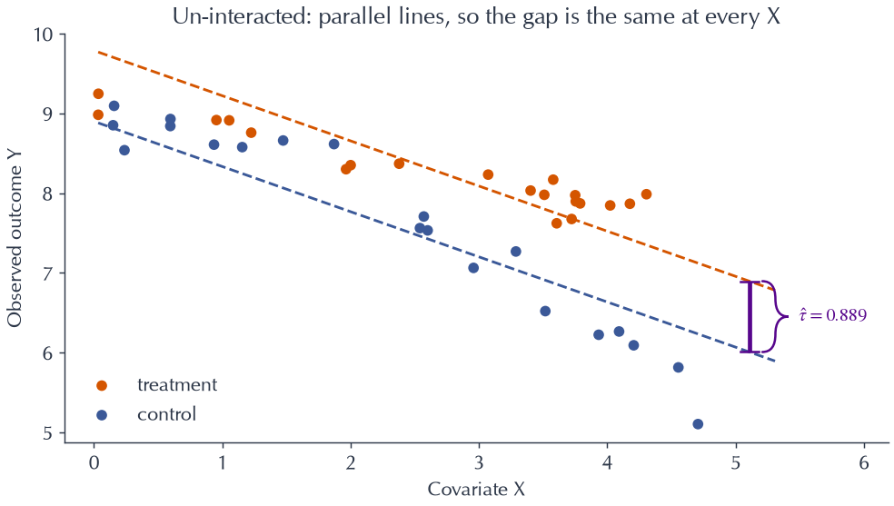

```python
# ols_hc2 gives the whole coefficient vector, so we can draw the lines and not just read tau.
design = np.stack(
    [np.ones((1, N_SAMPLE)), a_one.astype(float), (x_S - xbar_S)[None, :]], axis=2
)
beta, _ = ols_hc2(design, y_one)
intercept, tau_unint, slope = beta[0]

fig, ax = plt.subplots()
plot_experiment(ax)
ax.plot(grid, intercept + slope * (grid - xbar_S), color=COLORS["control"], ls="--", lw=1.6)
ax.plot(grid, intercept + tau_unint + slope * (grid - xbar_S),
        color=COLORS["treatment"], ls="--", lw=1.6)

x_gap = x_S.max() + 0.4  # clear of the data, where the parallel lines have room
base = intercept + slope * (x_gap - xbar_S)
effect_bracket(ax, x_gap, base, base + tau_unint, rf"$\hat\tau = {tau_unint:0.3f}$")
ax.set_title("Un-interacted: parallel lines, so the gap is the same at every X")
plt.show()
```

Lin's estimator fits **one line per arm**. Those lines are not parallel, so there is no single gap to report and the estimator has to choose where to measure it: at the grand mean of $X$.

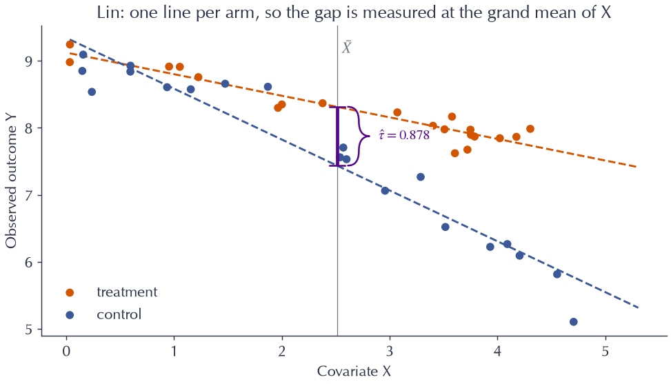

```python
fig, ax = plt.subplots()
plot_experiment(ax)

height = {}
for arm, label, colour in (
    (a_one[0], "treatment", COLORS["treatment"]),
    (~a_one[0], "control", COLORS["control"]),
):
    arm_slope, arm_intercept = np.polyfit(x_S[arm], y_one[0][arm], 1)
    ax.plot(grid, arm_intercept + arm_slope * grid, color=colour, ls="--", lw=1.6)
    height[label] = arm_intercept + arm_slope * xbar_S

ax.axvline(xbar_S, color=COLORS["neutral"], lw=0.7, zorder=1)
ax.annotate(r"$\bar X$", (xbar_S, ax.get_ylim()[1]), xytext=(4, -12),
            textcoords="offset points", color=COLORS["neutral"], va="top")

tau_lin = lin_adjust(x_S, y_one, a_one)[0][0]
effect_bracket(ax, xbar_S, height["control"], height["treatment"],
               rf"$\hat\tau = {tau_lin:0.3f}$")
ax.set_title("Lin: one line per arm, so the gap is measured at the grand mean of X")
plt.show()
```

The arm-wise lines are not parallel, because $\tau_i$ grows with $X$. The un-interacted fit splits the difference, so the gap it reports is not the gap at any particular $X$. That is Freedman's complaint in one picture. Lin's version commits to a point, and $\bar{X}$ is the choice that makes the estimate an average effect.

The two estimates are close here. With balanced arms the estimators have the same asymptotic variance, so this is the usual picture; Studies 1 and 2 are about the cases where it is not.

Both models are wrong: the truth is curved and these are straight lines. Neither estimator claims otherwise. The question is what being wrong costs.

## Study 1: Freedman's bias

Hold the sample fixed and re-randomise. Only the assignment moves, so the target is this sample's SATE and any systematic error is design-based bias, not sampling.

The slides derive an approximation for it. With $X$ centred,

$$\text{Bias}(\hat{\tau}) \approx -\frac{1}{N-1} \cdot \frac{\sum_i X_i^2 (\tau_i - \tau)}{\sum_i X_i^2}.$$

That is a leverage-weighted average of effect heterogeneity: nonzero when units with extreme $X$ have unusual treatment effects, zero when $\tau_i \equiv \tau$. We can evaluate it, because we made the data and know every $\tau_i$.

```python
def freedman_bias_formula(x, y0, y1):
    """The O(1/N) bias approximation from the slides, for one sample."""
    n = np.shape(x)[-1]
    xc = x - np.mean(x, axis=-1, keepdims=True)
    tau_i = y1 - y0
    tau_c = tau_i - np.mean(tau_i, axis=-1, keepdims=True)
    return -1 / (n - 1) * (xc**2 * tau_c).sum(-1) / (xc**2).sum(-1)
```

### Sample by sample

Draw 60 samples of $N = 40$ and re-randomise each 10,000 times. For each sample that gives a simulated bias with a Monte Carlo error, and a predicted bias from the formula. The dashed line is $y = x$ — drawn, not fitted.

```python
N_STUDY1_SAMPLES = 60
N_ASSIGNMENTS = 10_000

rows = []
for s in range(N_STUDY1_SAMPLES):
    xs, y0s, y1s = draw_potential_outcomes(N_SAMPLE, rng)
    sate_s = (y1s - y0s).mean()
    run = run_experiments(xs, y0s, y1s, N_TREATED, N_ASSIGNMENTS, rng)

    summary = by_method(
        run,
        bias=(pl.col("tau_hat") - pl.col("sate")).mean(),
        mcse=pl.col("tau_hat").std() / np.sqrt(N_ASSIGNMENTS),
    )
    rows.append(
        summary.with_columns(
            sample=pl.lit(s),
            predicted=pl.lit(float(freedman_bias_formula(xs, y0s, y1s))),
        )
    )

study1 = pl.concat(rows)
print(f"{N_STUDY1_SAMPLES} samples x {N_ASSIGNMENTS:,} assignments = "
      f"{N_STUDY1_SAMPLES * N_ASSIGNMENTS:,} experiments per estimator")
```

```
60 samples x 10,000 assignments = 600,000 experiments per estimator
```

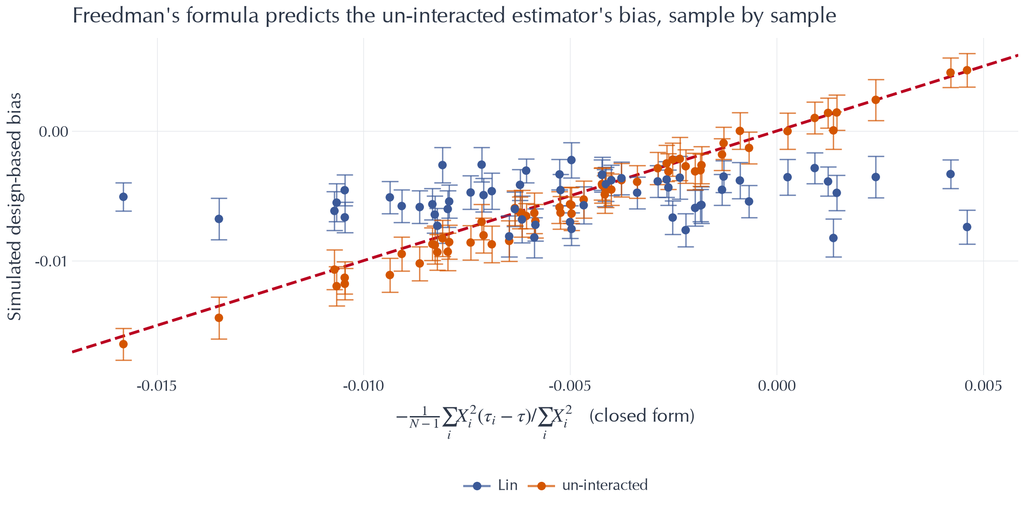

```python
(
    p9.ggplot(
        study1.filter(pl.col("method") != "unadjusted"),
        p9.aes(x="predicted", y="bias", color="method"),
    )
    + p9.geom_abline(slope=1, intercept=0, color=COLORS["truth"], linetype="dashed", size=1.0)
    + p9.geom_errorbar(
        p9.aes(ymin="bias - 1.96 * mcse", ymax="bias + 1.96 * mcse"), width=0.0004, alpha=0.7
    )
    + p9.geom_point(size=2.0)
    + scale_color_cml()
    + p9.labs(
        title="Freedman's formula predicts the un-interacted estimator's bias, sample by sample",
        x=r"$-\frac{1}{N-1}\sum_i X_i^2(\tau_i - \tau) / \sum_i X_i^2$   (closed form)",
        y="Simulated design-based bias",
        color="",
    )
)
```

```python
by_method(
    study1,
    **{
        "mean bias": pl.col("bias").mean().round(5),
        "mean predicted": pl.col("predicted").mean().round(5),
        "corr(bias, predicted)": pl.corr("bias", "predicted").round(3),
        "samples with |bias| > 2 MC errors": (pl.col("bias").abs() > 2 * pl.col("mcse")).mean(),
    },
)
```

shape: (3, 5)

| method str | mean bias f64 | mean predicted f64 | corr(bias, predicted) f64 | samples with \|bias\| > 2 MC errors f64 |
| --- | --- | --- | --- | --- |
| "unadjusted" | -0.00009 | -0.00476 | 0.028 | 0.016667 |
| "un-interacted" | -0.0053 | -0.00476 | 0.992 | 0.916667 |
| "Lin" | -0.0051 | -0.00476 | 0.195 | 1.0 |

The `mean predicted` column is the same in all three rows: the formula is a property of the *sample*, not the estimator, and Freedman derives it for the un-interacted regression. Three things to read off.

**The bias is real.** The un-interacted estimator misses this sample's SATE systematically — in 92% of the 60 samples by more than two Monte Carlo errors, always in the direction the formula says. The unadjusted estimator does not: one sample of 60 clears that bar, as noise should.

**The formula is right.** The correlation between prediction and simulation is $0.99$, and the points sit on $y = x$, not on some other line through the origin. We have identified the bias, not merely observed it — including its sign, which is positive for a few samples.

**Lin does not fix it.** Its average bias is the same size ($-0.0051$, against $-0.0053$ for the un-interacted estimator), but it is not the *same quantity*: its correlation with the prediction is $0.20$, and on the plot it forms a horizontal band at roughly the right height rather than a line. Interacting changes which $O(1/N)$ term you get, not whether you get one. It fixes the variance instead, which is Study 2.

### Does it vanish at rate $1/N$?

Freedman's defence of adjustment rests on the rate. Run the whole thing on a ladder of sample sizes, drawing a **fresh sample per replication** so the target is the population ATE and the numbers are comparable across $N$. If the bias is $O(1/N)$, then $N \times \text{bias}$ is roughly constant.

One choice here matters. We could compare $\hat{\tau}$ to the population ATE, but each replication also gives us the SATE of the sample it drew, and $\mathbb{E}[\tau_{\mathcal{S}}] = \text{ATE}$ exactly, so $\mathbb{E}[\hat{\tau} - \tau_{\mathcal{S}}]$ is the same quantity. It is also the more faithful one, since Freedman's bias is conditional on the sample, and it is cheaper: differencing against $\tau_{\mathcal{S}}$ cancels the sampling variability the two share. That halves the Monte Carlo error, which is worth as much as quadrupling the replications.

```python
def bias_ladder_row(n, reps, rng):
    """Average design-based bias, with a fresh sample per replication."""
    x, y0, y1 = draw_potential_outcomes((reps, n), rng)
    run = run_experiments(x, y0, y1, n // 2, reps, rng)
    error = pl.col("tau_hat") - pl.col("sate")  # paired: each estimate against its own sample
    return by_method(
        run,
        bias=error.mean(),
        mcse=error.std() / np.sqrt(reps),
    ).with_columns(n=pl.lit(n), predicted=pl.lit(float(freedman_bias_formula(x, y0, y1).mean())))


N_GRID = [20, 40, 80, 160, 320]
REPS_PER_N = 50_000

ladder = pl.concat([bias_ladder_row(n, REPS_PER_N, rng) for n in N_GRID])
print(f"{len(N_GRID)} sample sizes x {REPS_PER_N:,} replications")
```

```
5 sample sizes x 50,000 replications
```

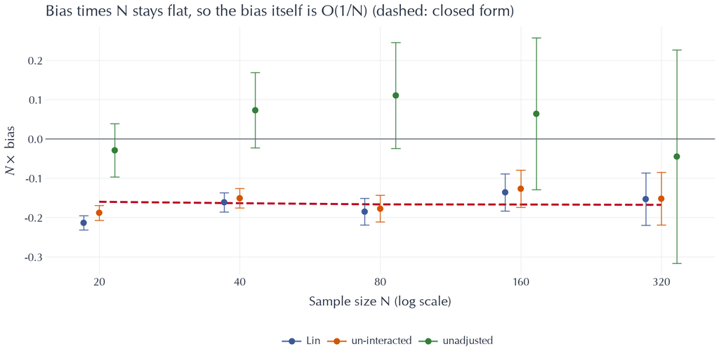

```python
ladder_plot = ladder.with_columns(
    scaled=pl.col("n") * pl.col("bias"),
    scaled_lo=pl.col("n") * (pl.col("bias") - 1.96 * pl.col("mcse")),
    scaled_hi=pl.col("n") * (pl.col("bias") + 1.96 * pl.col("mcse")),
    scaled_predicted=pl.col("n") * pl.col("predicted"),
)

(
    p9.ggplot(ladder_plot, p9.aes(x="n", color="method"))
    + p9.geom_hline(yintercept=0, color=COLORS["neutral"], size=0.5)
    + p9.geom_line(
        p9.aes(y="scaled_predicted"),
        data=ladder_plot.filter(pl.col("method") == "un-interacted"),
        color=COLORS["truth"],
        linetype="dashed",
        size=1.0,
    )
    + p9.geom_errorbar(
        p9.aes(ymin="scaled_lo", ymax="scaled_hi"),
        width=0.06,
        alpha=0.8,
        position=p9.position_dodge(width=0.10),
    )
    + p9.geom_point(p9.aes(y="scaled"), size=2.2, position=p9.position_dodge(width=0.10))
    + scale_color_cml()
    + p9.scale_x_log10(breaks=N_GRID, labels=[str(n) for n in N_GRID])
    + p9.labs(
        title="Bias times N stays flat, so the bias itself is O(1/N) (dashed: closed form)",
        x="Sample size N (log scale)",
        y=r"$N \times$ bias",
        color="",
    )
)
```

Three claims at once.

The dashed line is $N$ times Freedman's formula. It is **flat**, at about $-0.16$: the $O(1/N)$ rate drawn as a horizontal line. Both adjusted estimators track it, scattering around the dashed line rather than falling towards zero, at every $N$ from 20 to 320. The unadjusted estimator scatters around **zero** instead, with error bars that always cover it. That is the Week 1 guarantee, and the contrast this study rests on.

Two caveats. Both adjusted estimators overshoot the prediction at $N = 20$ by a little more than Monte Carlo error, as expected: the derivation drops terms of order $1/N^2$, and the formula is for the un-interacted estimator. And the error bars grow like $\sqrt{N}$, so the right-hand end says the least — the scatter there is noise. Resolving a bias of half a thousandth is not free even with the paired comparison. The unadjusted bars are three to four times wider again, because the difference in means is much noisier to begin with.

## Study 2: variance, and when adjustment hurts

Bias is not what Freedman is most worried about. His Theorems 3 and 4 concern the asymptotic variance, and the slides reduce the comparison to two numbers computed from a standardised covariate ($\bar{X} = 0$, $\frac{1}{N}\sum_i X_i^2 = 1$):

$$c_{\text{lvl}} = \frac{1}{N}\sum_i \alpha_i X_i, \qquad c_{\text{het}} = \frac{1}{N}\sum_i (\tau_i - \tau) X_i,$$

where $\alpha_i = \pi(Y_i(1) - \mu_1) + (1 - \pi)(Y_i(0) - \mu_0)$ is unit $i$'s level, averaged over the randomisation distribution. Does $X$ predict the level, and does it predict the effect?

The reduction in variance from adjusting is $\Delta / (N\pi(1-\pi))$, with

$$\Delta_{\text{un-int}} = c_{\text{lvl}}\big[c_{\text{lvl}} + 2(1 - 2\pi)c_{\text{het}}\big], \qquad \Delta_{\text{Lin}} = \big[c_{\text{lvl}} + (1 - 2\pi)c_{\text{het}}\big]^2 .$$

Lin's is a square, so it cannot be negative. Freedman's is a square *plus a cross term*, and the cross term can dominate. The two differ by exactly $(1-2\pi)^2 c_{\text{het}}^2$, the "incomplete square" claim on the slides, and that difference vanishes at $\pi = 1/2$.

We can compute all of this and compare it to simulated variances. Take one large fixed sample — large because these are asymptotic statements — and sweep the treated share $\pi$.

```python
N_STUDY2 = 2_000
N_RANDOMISATIONS = 30_000

x2, y0_2, y1_2 = draw_potential_outcomes(N_STUDY2, rng)

# Standardise X, as the slides require, so the c's are comparable across covariates.
x2_std = (x2 - x2.mean()) / x2.std()
tau_i = y1_2 - y0_2
mu1, mu0 = y1_2.mean(), y0_2.mean()

c_het = np.mean((tau_i - tau_i.mean()) * x2_std)
print(f"c_het (X predicts the effect): {c_het:+0.4f}")
print(f"SATE of this sample:           {tau_i.mean():+0.4f}")
```

```
c_het (X predicts the effect): +0.6685
SATE of this sample:           +0.8440
```

```python
def freedman_deltas(pi):
    """The two Delta's from the slides, and the level coefficient they depend on."""
    alpha = pi * (y1_2 - mu1) + (1 - pi) * (y0_2 - mu0)
    c_lvl = np.mean(alpha * x2_std)
    return {
        "pi": pi,
        "c_lvl": c_lvl,
        "un-interacted": c_lvl * (c_lvl + 2 * (1 - 2 * pi) * c_het),
        "Lin": (c_lvl + (1 - 2 * pi) * c_het) ** 2,
    }


PI_GRID = [0.05, 0.1, 0.15, 0.2, 0.3, 0.4, 0.5, 0.6, 0.7, 0.8, 0.9]

rows = []
for pi in PI_GRID:
    n1 = int(round(pi * N_STUDY2))
    deltas = freedman_deltas(pi)
    denominator = N_STUDY2 * pi * (1 - pi)

    run = run_experiments(x2, y0_2, y1_2, n1, N_RANDOMISATIONS, rng)
    wide = run.pivot(on="method", index="rep", values="tau_hat")

    # Paired Monte Carlo error: the same assignments feed every estimator, so difference the
    # squared deviations replication by replication rather than the variances.
    dev = {m: (wide[m] - wide[m].mean()).to_numpy() ** 2 for m in METHOD_ORDER}
    var_unadjusted = dev["unadjusted"].mean()

    for method in ("un-interacted", "Lin"):
        gap = dev["unadjusted"] - dev[method]
        # Relative efficiency: how many times smaller the adjusted variance is. The closed form
        # predicts the *gap*, so turn it into a ratio using the same unadjusted variance.
        rows.append({
            "pi": pi,
            "method": method,
            "delta": deltas[method],
            "ratio": var_unadjusted / dev[method].mean(),
            "ratio_predicted": var_unadjusted / (var_unadjusted - deltas[method] / denominator),
            "ratio_lo": var_unadjusted / (dev[method].mean() + 1.96 * gap.std(ddof=1)
                                          / np.sqrt(N_RANDOMISATIONS)),
            "ratio_hi": var_unadjusted / (dev[method].mean() - 1.96 * gap.std(ddof=1)
                                          / np.sqrt(N_RANDOMISATIONS)),
        })

study2 = pl.from_dicts(rows)
print(f"{len(PI_GRID)} treated shares x {N_RANDOMISATIONS:,} randomisations")
```

```
11 treated shares x 30,000 randomisations
```

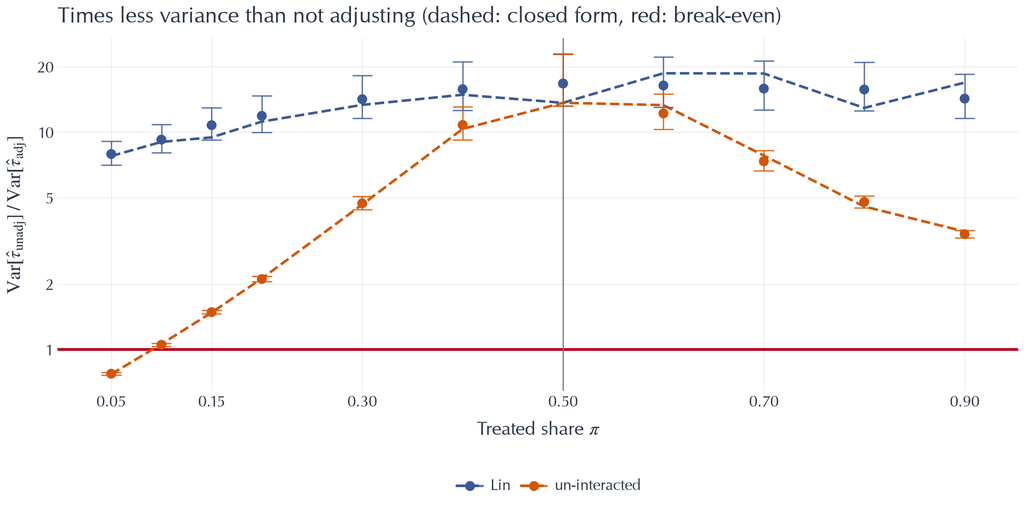

```python
(
    p9.ggplot(study2, p9.aes(x="pi", color="method"))
    + p9.geom_hline(yintercept=1, color=COLORS["truth"], size=1.0)
    + p9.geom_vline(xintercept=0.5, color=COLORS["neutral"], size=0.4)
    + p9.geom_line(p9.aes(y="ratio_predicted"), linetype="dashed", size=0.9)
    + p9.geom_errorbar(p9.aes(ymin="ratio_lo", ymax="ratio_hi"), width=0.02, alpha=0.8)
    + p9.geom_point(p9.aes(y="ratio"), size=2.5)
    + scale_color_cml()
    + p9.scale_x_continuous(breaks=PI_GRID[::2])
    + p9.scale_y_log10(breaks=[1, 2, 5, 10, 20, 50])
    + p9.labs(
        title="Times less variance than not adjusting (dashed: closed form, red: break-even)",
        x=r"Treated share $\pi$",
        y=r"$\mathrm{Var}[\hat\tau_{\mathrm{unadj}}] \,/\, \mathrm{Var}[\hat\tau_{\mathrm{adj}}]$",
        color="",
    )
)
```

The ratio is how many times less variance adjusting gives you. The red line at 1 is break-even; below it, the adjustment cost precision. Every point sits on its dashed closed form across the whole grid, over a twenty-fold range of ratios: an asymptotic formula holding to within Monte Carlo error at $N = 2{,}000$.

At $\pi = 0.05$ Lin's estimator gives about **eight times** less variance and the un-interacted estimator about **0.8 times** — adjusting for a covariate that explains almost all of the outcome made the estimate *worse than not adjusting at all*. It crosses break-even between $\pi = 0.05$ and $\pi = 0.1$ on this DGP, and is only just above 1 at $\pi = 0.1$.

The un-interacted curve peaks near $\pi = 0.5$ and falls away on both sides, to about 3 at $\pi = 0.9$; Lin's stays between 8 and 19 everywhere. Unequal arms cost the un-interacted estimator most of its advantage in both directions, and push it below break-even on one.

That is Freedman's sharpest point, and not a small-sample artefact: the closed form predicts it. It takes both ingredients — unequal arms, so $1 - 2\pi \neq 0$, and a covariate that predicts heterogeneity, so $c_{\text{het}} \neq 0$. Here $c_{\text{lvl}} < 0$ and $c_{\text{het}} > 0$, so the cross term is negative when $\pi < 1/2$; with the signs reversed the damage would appear for $\pi > 1/2$ instead. Under the sharp null $c_{\text{het}} = 0$ and neither curve can dip below break-even.

The curves meet at $\pi = 1/2$, where, as Bai et al. note, interacting gains nothing asymptotically. They separate in both directions, by exactly $(1 - 2\pi)^2 c_{\text{het}}^2$ in the variance gap:

```python
identity_gap = (
    study2.pivot(on="method", index="pi", values="delta")
    .with_columns(
        difference=pl.col("Lin") - pl.col("un-interacted"),
        formula=(1 - 2 * pl.col("pi")) ** 2 * c_het**2,
    )
    .select((pl.col("difference") - pl.col("formula")).abs().max())
    .item()
)
print(f"max |(Delta_Lin - Delta_unint) - (1-2pi)^2 c_het^2| over the grid: {identity_gap:.2e}")
```

```
max |(Delta_Lin - Delta_unint) - (1-2pi)^2 c_het^2| over the grid: 1.53e-16
```

Zero to machine precision: Freedman's expression is Lin's square with a term missing.

### What the standard errors say

A variance ratio is what an analyst would have got; a standard error is what they report. The two can come apart, so check them at $\pi = 1/2$ and at $\pi = 0.1$. Both adjusted estimators use HC2, which Lin argues is the right choice.

```python
rows = []
for pi in (0.5, 0.1):
    n1 = int(round(pi * N_STUDY2))
    run = run_experiments(x2, y0_2, y1_2, n1, N_RANDOMISATIONS, rng)
    rows.append(
        by_method(
            run,
            **{
                "SD of estimates": pl.col("tau_hat").std().round(4),
                "mean SE": pl.col("se_hat").mean().round(4),
                "SE / SD": (pl.col("se_hat").mean() / pl.col("tau_hat").std()).round(3),
                "coverage of SATE": (
                    (pl.col("tau_hat") - pl.col("sate")).abs() <= Z95 * pl.col("se_hat")
                ).mean().round(4),
            },
        ).with_columns(pi=pl.lit(pi))
    )
pl.concat(rows).select("pi", "method", pl.exclude("pi", "method"))
```

shape: (6, 6)

| pi f64 | method str | SD of estimates f64 | mean SE f64 | SE / SD f64 | coverage of SATE f64 |
| --- | --- | --- | --- | --- | --- |
| 0.5 | "unadjusted" | 0.0379 | 0.0414 | 1.091 | 0.9676 |
| 0.5 | "un-interacted" | 0.0093 | 0.0192 | 2.052 | 1.0 |
| 0.5 | "Lin" | 0.0093 | 0.012 | 1.282 | 0.9876 |
| 0.1 | "unadjusted" | 0.0437 | 0.0467 | 1.068 | 0.9624 |
| 0.1 | "un-interacted" | 0.0427 | 0.0456 | 1.069 | 0.9629 |
| 0.1 | "Lin" | 0.0144 | 0.0162 | 1.123 | 0.9717 |

Every row is conservative, and part of that is the Week 1 story: $\hat{V}$ ignores the unidentifiable variance of the unit-level effects. Adjustment shrinks the identified part and leaves that part alone, so the ratio rises as the estimator gets better — $1.09$ for the unadjusted estimator and $1.28$ for Lin's at $\pi = 1/2$, for identical nominal coverage claims.

The un-interacted row at $\pi = 1/2$ is a different problem. It is exactly as *efficient* as Lin's there — both have $\text{SD} = 0.0093$, which is what $\Delta_{\text{un-int}} = \Delta_{\text{Lin}}$ at $\pi = 1/2$ promised — but it reports a standard error **twice too large** and covers the SATE 100% of the time. Its residuals carry the interaction it did not fit, so the residual variance measures misspecification rather than sampling noise. This is Freedman's other complaint, that nominal variances are off *"by factors that are quite large"*. Note the direction: you lose power, not honesty.

At $\pi = 0.1$ the picture inverts. The un-interacted standard error is now about right ($1.07$) and the efficiency has gone: $\text{SD} = 0.0427$ against $0.0437$ unadjusted, a 2% gain, matching the near-zero $\Delta$ from the sweep. Lin's cuts the standard deviation by a factor of three. One specification is inefficient with well-behaved standard errors, the other efficient with badly behaved ones, and which you get depends on $\pi$ rather than on anything visible in the data.

## Study 3: Aronow and Middleton — unbiasedness for free

The last two studies were about a *particular* adjustment being biased. Aronow and Middleton turn it round: adjustment is exactly unbiased for **any** function $f$, at every $N$, as long as the assignment cannot see it. Start from Horvitz–Thompson and subtract $f$ before weighting:

$$\hat{\tau}_G = \frac{1}{N}\sum_i\left[\frac{A_i(Y_i - f_i)}{\pi_{1i}} - \frac{(1 - A_i)(Y_i - f_i)}{\pi_{0i}}\right].$$

The framework needs a design where the difference in means is not already right, so let the propensity depend on $X$ and assign independently across units:

$$\pi_{1i} = 0.3 + 0.4\,(X_i / 5) \in [0.3, 0.7].$$

Units with high $X$ — the ones with large treatment effects — are more likely to be treated. The difference in means will be badly wrong; Horvitz–Thompson will not.

```python
N_STUDY3 = 100
REPS_STUDY3 = 100_000

x3, y0_3, y1_3 = draw_potential_outcomes(N_STUDY3, rng)
sate3 = (y1_3 - y0_3).mean()

pi1 = 0.3 + 0.4 * (x3 / 5)  # known by design
pi0 = 1 - pi1
print(f"propensities range over [{pi1.min():0.3f}, {pi1.max():0.3f}]")
print(f"SATE of this sample: {sate3:0.4f}")
```

```
propensities range over [0.308, 0.698]
SATE of this sample: 0.8654
```

```python
def generalized_difference(y, a, f, pi1, pi0):
    """Aronow & Middleton's generalized difference estimator. `f` may be (n,) or (reps, n)."""
    return ((a * (y - f)) / pi1 - ((1 - a) * (y - f)) / pi0).mean(-1)
```

Five choices of $f$, four of them fixed before the experiment and one of them not:

1. $f = 0$: plain Horvitz–Thompson.
2. $f = c$, a constant guessed in advance. The slides list this as "already a variance improvement": recentring costs nothing and does something.
3. $f = \hat{\theta}'X$ fit on a **pilot experiment**: an independent draw of 400 units from the same DGP, which the assignment in our experiment cannot depend on.
4. $f = \hat{\theta}'X$ fit on the **realised experiment itself**. This is the version that breaks the condition.
5. The difference in means, for reference, which ignores the propensities.

```python
# The pilot: an independent experiment, run before ours, on 400 units from the same DGP.
x_pilot, y0_pilot, y1_pilot = draw_potential_outcomes(400, rng)
a_pilot = rng.random(400) < 0.5
y_pilot = np.where(a_pilot, y1_pilot, y0_pilot)

theta_pilot = np.polyfit(x_pilot, y_pilot, 1)
f_pilot = np.polyval(theta_pilot, x3)
f_constant = np.full(N_STUDY3, y_pilot.mean())  # a guess at the level, from the pilot

print(f"pilot fit: y = {theta_pilot[1]:0.3f} {theta_pilot[0]:+0.3f} x")
print(f"constant guess: {f_constant[0]:0.3f}")
```

```
pilot fit: y = 9.339 -0.593 x
constant guess: 7.819
```

```python
a3 = (rng.random((REPS_STUDY3, N_STUDY3)) < pi1).astype(float)
y3 = np.where(a3.astype(bool), y1_3, y0_3)

# f fit on the realised experiment: pooled OLS of Y on X, one fit per replication.
xc3 = x3 - x3.mean()
slope = (y3 * xc3).sum(-1) / (xc3**2).sum()
f_insample = y3.mean(-1)[:, None] + slope[:, None] * xc3

n1_3, n0_3 = a3.sum(-1), (1 - a3).sum(-1)
estimates = {
    "HT, f = 0": generalized_difference(y3, a3, 0.0, pi1, pi0),
    "HT, f = constant": generalized_difference(y3, a3, f_constant, pi1, pi0),
    "HT, f from pilot": generalized_difference(y3, a3, f_pilot, pi1, pi0),
    "HT, f fit in-sample": generalized_difference(y3, a3, f_insample, pi1, pi0),
    "difference in means": (y3 * a3).sum(-1) / n1_3 - (y3 * (1 - a3)).sum(-1) / n0_3,
}

study3 = pl.from_dicts([
    {
        "estimator": name,
        "bias": v.mean() - sate3,
        "mcse": v.std(ddof=1) / np.sqrt(REPS_STUDY3),
        "sd": v.std(ddof=1),
    }
    for name, v in estimates.items()
])
study3.select(
    "estimator",
    Bias=pl.col("bias").round(5),
    **{
        "MC error": pl.col("mcse").round(5),
        "Bias / MC error": (pl.col("bias") / pl.col("mcse")).round(1),
        "SD of estimates": pl.col("sd").round(4),
    },
)
```

shape: (5, 5)

| estimator str | Bias f64 | MC error f64 | Bias / MC error f64 | SD of estimates f64 |
| --- | --- | --- | --- | --- |
| "HT, f = 0" | -0.00201 | 0.0051 | -0.4 | 1.6122 |
| "HT, f = constant" | -0.00071 | 0.00071 | -1.0 | 0.2253 |
| "HT, f from pilot" | -0.00034 | 0.00023 | -1.5 | 0.0737 |
| "HT, f fit in-sample" | -0.01985 | 0.00029 | -67.4 | 0.0932 |
| "difference in means" | -0.42684 | 0.00056 | -764.6 | 0.1765 |

All three fixed choices of $f$ are unbiased, within one and a half Monte Carlo errors, at $N = 100$ and with no asymptotics. Their standard deviations span a factor of **twenty-two**: recentring by a constant guessed from the pilot takes $1.61$ down to $0.23$, and the pilot's fitted line takes it to $0.074$. The choice of $f$ does nothing to the bias and almost everything to the variance, which is the claim. Most of the gain came from the constant, because HT's variance is driven by the size of $Y$, and any fixed number near the middle of it helps.

The difference in means sits 765 Monte Carlo errors from the truth: a bias of $-0.427$ against an effect of $0.865$, nearly half the estimand. Unequal propensities are a case where Week 1's design-based guarantee does not apply, and knowing $\pi_{1i}$ is what restores it.

### The one that breaks

The in-sample fit is biased. The slides give the size of the damage exactly:

$$\text{Bias}(\hat{\tau}_G) = -\frac{1}{N}\sum_i \text{Cov}\big(A_i, f(X_i, \theta_i)\big)\left(\frac{1}{\pi_{1i}} + \frac{1}{\pi_{0i}}\right).$$

With 100,000 replications we can estimate each unit's $\text{Cov}(A_i, f_i)$ directly and evaluate it.

```python
cov_a_f = ((a3 - pi1) * (f_insample - f_insample.mean(0))).mean(0)
predicted_bias = -np.mean(cov_a_f * (1 / pi1 + 1 / pi0))
simulated_bias = estimates["HT, f fit in-sample"].mean() - sate3

print(f"predicted bias  {predicted_bias:+0.5f}")
print(f"simulated bias  {simulated_bias:+0.5f}")
print(f"MC error        {estimates['HT, f fit in-sample'].std(ddof=1) / np.sqrt(REPS_STUDY3):0.5f}")
```

```
predicted bias  -0.01947
simulated bias  -0.01985
MC error        0.00029
```

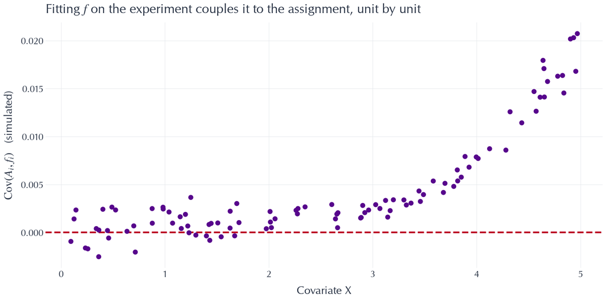

```python
(
    p9.ggplot(
        pl.DataFrame({"x": x3, "cov": cov_a_f}),
        p9.aes(x="x", y="cov"),
    )
    + p9.geom_hline(yintercept=0, color=COLORS["truth"], linetype="dashed", size=1.0)
    + p9.geom_point(size=2.0, color=COLORS["estimate"])
    + p9.labs(
        title=r"Fitting $f$ on the experiment couples it to the assignment, unit by unit",
        x="Covariate X",
        y=r"$\mathrm{Cov}(A_i, f_i)$   (simulated)",
    )
)
```

The two agree to $0.0004$, a little over one Monte Carlo error. The prediction is itself simulated — we estimated each $\text{Cov}(A_i, f_i)$ from the same replications — so it carries error of its own.

The plot shows where the coupling comes from. Treating unit $i$ replaces $Y_i(0)$ with $Y_i(1)$ in the data the regression sees, raising it by $\tau_i$ and pulling the fitted line up near $X_i$. So $\text{Cov}(A_i, f_i)$ tracks the unit's own treatment effect, and in this DGP $\tau_i$ grows with $X$: the covariance is negligible at the bottom of the range and largest at the top. Nothing is wrong with the regression. The problem is that it read the outcomes.

The bias is $0.020$ — about a fifth of that estimator's standard deviation, 67 Monte Carlo errors from zero, and the same order as Freedman's. Violating the condition is a real bias, not a catastrophe. The fix is structural rather than statistical: there is no assumption to make about $f$, no model to get right, no rate to appeal to. Either the adjustment sees the outcomes or it does not, and the slides list the ways to arrange the second: a pilot, pre-specification, sample splitting, cross-fitting.

## Study 4: Bloniarz et al. — when $p$ is large

Everything so far had one covariate. Lin's fix fits OLS **separately in each arm**, so it inverts an arm-level $X'X$ built from $N_a$ rows and $p$ columns. Once $p$ approaches $N_a$ that regression overfits, and the estimator inherits the problem.

This needs a different DGP: many covariates, only a few of which matter.

$$X_i \sim \mathcal{N}(0, I_p), \qquad Y_i(0) = X_i'\beta + \varepsilon_i, \qquad Y_i(1) = Y_i(0) + \tau + X_i'\gamma,$$

with $\beta$ and $\gamma$ nonzero on the same $s$ coordinates and $\varepsilon_i \sim \mathcal{N}(0,1)$. The effect is heterogeneous, the same few covariates drive both the level and the heterogeneity, and $\tau$ is known. We take $N = 200$, $p = 80$, $s = 5$, so arm-wise OLS fits 80 regressors to 100 rows: estimable and useless.

```python
from sklearn.linear_model import LassoCV

N_STUDY4, P_STUDY4, S_STUDY4, TAU_STUDY4 = 200, 80, 5, 1.0

beta = np.zeros(P_STUDY4)
gamma = np.zeros(P_STUDY4)
beta[:S_STUDY4] = rng.normal(0, 1.5, S_STUDY4)
gamma[:S_STUDY4] = rng.normal(0, 0.5, S_STUDY4)


def draw_sparse_sample(n, rng):
    X = rng.normal(size=(n, P_STUDY4))
    y0 = X @ beta + rng.normal(0, 1, n)
    y1 = y0 + TAU_STUDY4 + X @ gamma
    return X, y0, y1
```

The estimator is Lin's, unchanged. The slides stress that nothing changes but the fit, and `arm_wise_adjust` in the class package takes the arm-wise fit as an argument:

```
b = fit(Xc, yc)                                    # <- the only thing that varies
tau_hat += sign * (ya.mean() - (Xa.mean(0) - xbar) @ b)
```

`tests/test_estimators.py` checks that an OLS fit reproduces `lin_adjust` exactly, and that a zero fit reproduces the difference in means. So the four rows below are one estimator with four fits.

```python
def fit_none(Xc, yc):
    """No adjustment: this reduces arm_wise_adjust to the difference in means."""
    return np.zeros(Xc.shape[1])


def fit_ols(Xc, yc):
    return np.linalg.lstsq(Xc, yc, rcond=None)[0]


def fit_lasso(Xc, yc):
    return LassoCV(cv=5, max_iter=50_000, fit_intercept=False).fit(Xc, yc).coef_


def fit_lasso_ols(Xc, yc):
    """cv(Lasso+OLS): the Lasso selects, OLS estimates. What the paper recommends in practice."""
    b = fit_lasso(Xc, yc)
    selected = np.abs(b) > 0
    out = np.zeros_like(b)
    if 0 < selected.sum() < Xc.shape[0] - 1:
        out[selected] = np.linalg.lstsq(Xc[:, selected], yc, rcond=None)[0]
    return out


FITS = {
    "unadjusted": fit_none,
    "Lin (arm-wise OLS)": fit_ols,
    "Lasso": fit_lasso,
    "cv(Lasso+OLS)": fit_lasso_ols,
}
```

A cross-validated Lasso cannot be vectorised across replications, so this study runs one at a time: 300 replications rather than tens of thousands, with correspondingly larger Monte Carlo errors. Fresh sample per replication, one assignment each, $\pi = 1/2$.

```python
REPS_STUDY4 = 300

records = []
for r in range(REPS_STUDY4):
    X4, y0_4, y1_4 = draw_sparse_sample(N_STUDY4, rng)
    sate4 = (y1_4 - y0_4).mean()
    a4 = complete_randomisation(1, N_STUDY4, N_STUDY4 // 2, rng)[0]
    y4 = np.where(a4, y1_4, y0_4)

    for name, fit in FITS.items():
        tau_hat, se_hat = arm_wise_adjust(X4, y4, a4, fit)
        records.append({
            "method": name,
            "tau_hat": tau_hat,
            "se_hat": se_hat,
            "sate": sate4,
        })

study4 = pl.from_dicts(records)
print(f"{REPS_STUDY4} replications x {len(FITS)} fits")
```

```
300 replications x 4 fits
```

```python
(
    study4.group_by("method")
    .agg(
        bias=(pl.col("tau_hat") - TAU_STUDY4).mean(),
        mcse=pl.col("tau_hat").std() / np.sqrt(REPS_STUDY4),
        sd=pl.col("tau_hat").std(),
        mean_se=pl.col("se_hat").mean(),
        coverage=(
            (pl.col("tau_hat") - pl.col("sate")).abs() <= Z95 * pl.col("se_hat")
        ).mean(),
    )
    .with_columns(_o=pl.col("method").replace_strict(list(FITS), list(range(len(FITS)))))
    .sort("_o")
    .select(
        "method",
        Bias=pl.col("bias").round(4),
        **{
            "MC error": pl.col("mcse").round(4),
            "SD of estimates": pl.col("sd").round(4),
            "mean SE": pl.col("mean_se").round(4),
            "SE / SD": (pl.col("mean_se") / pl.col("sd")).round(3),
            "coverage of SATE": pl.col("coverage").round(3),
        },
    )
)
```

shape: (4, 7)

| method str | Bias f64 | MC error f64 | SD of estimates f64 | mean SE f64 | SE / SD f64 | coverage of SATE f64 |
| --- | --- | --- | --- | --- | --- | --- |
| "unadjusted" | 0.0242 | 0.0217 | 0.376 | 0.3811 | 1.013 | 0.957 |
| "Lin (arm-wise OLS)" | 0.0181 | 0.0155 | 0.2684 | 0.0617 | 0.23 | 0.37 |
| "Lasso" | 0.0202 | 0.0103 | 0.1784 | 0.1286 | 0.721 | 0.927 |
| "cv(Lasso+OLS)" | 0.0183 | 0.0108 | 0.1864 | 0.1099 | 0.589 | 0.823 |

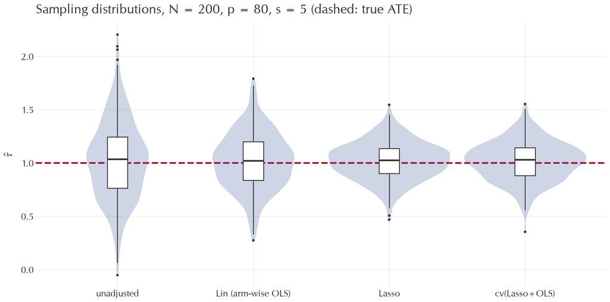

```python
(
    p9.ggplot(study4, p9.aes(x="method", y="tau_hat"))
    + p9.geom_hline(yintercept=TAU_STUDY4, color=COLORS["truth"], linetype="dashed", size=1.0)
    + p9.geom_violin(fill=COLORS["control"], alpha=0.25, color="none")
    + p9.geom_boxplot(width=0.15, fill="white", outlier_size=0.5)
    + p9.scale_x_discrete(limits=list(FITS))
    + p9.labs(
        title=f"Sampling distributions, N = {N_STUDY4}, p = {P_STUDY4}, s = {S_STUDY4} (dashed: true ATE)",
        x="",
        y=r"$\hat\tau$",
    )
)
```

The point estimates and the standard errors tell opposite stories.

**The point estimates behave as advertised.** Every fit beats no adjustment, and every fit is unbiased to within Monte Carlo error: at $N = 200$ with 300 replications, Freedman's $O(1/N)$ term is below the noise. Arm-wise OLS cuts the standard deviation by 29%, from $0.376$ to $0.268$, even with 80 regressors chasing 5 signals. The Lasso takes it to $0.178$, a 53% reduction, comfortably satisfying Corollary 1's "no worse than unadjusted". `cv(Lasso+OLS)` lands in the same place.

**The standard errors do not.** Arm-wise OLS reports a standard error four times too small ($\text{SE}/\text{SD} = 0.23$), and its 95% intervals cover the SATE 37% of the time. That is the failure Bloniarz et al. describe: with $p$ near $N_a$ the arm-wise fit interpolates much of its own noise, so the in-sample residuals are far smaller than the errors they stand in for. The Lasso is much better, at $0.72$ and 93% coverage. `cv(Lasso+OLS)` is worse than the plain Lasso, because refitting the selected coefficients by OLS shrinks the residuals again without shrinking the true error.

Week 1's conservativeness was acceptable because it errs in the safe direction. This errs in the other, and it is invisible from inside a single experiment: arm-wise OLS reports a tight interval with no sign that it is wrong. The unadjusted estimator over-covers at 96%, as Week 1 said it would.

### Is this DGP inside the theory?

Bloniarz et al. need $s \log p \ll \sqrt{n}$, and note that their own application does not manage it.

```python
s_log_p_over_root_n = S_STUDY4 * np.log(P_STUDY4) / np.sqrt(N_STUDY4)
print(f"s log(p) / sqrt(n) = {s_log_p_over_root_n:0.2f}")
```

```
s log(p) / sqrt(n) = 1.55
```

Their own application comes out at $3.55$, which they call *"not close to zero"*. Ours is $1.55$: smaller, and still not close to zero.

So we are in the same position they are. The point estimates behave anyway; the intervals are what suffers. When the asymptotic condition fails, inference breaks before estimation does.

## What to take away

1. **Freedman's bias is real, identified, and $O(1/N)$.** Study 1's closed form tracked the un-interacted estimator's bias sample by sample at a correlation of $0.99$, and $N \times \text{bias}$ did not shrink along a ladder from $N = 20$ to $N = 320$. It is a leverage-weighted average of effect heterogeneity, so it is zero exactly when $\tau_i$ is constant. The difference in means had no bias at any $N$: that is the guarantee you trade away, and Lin's estimator does not restore it.
2. **Adjustment can raise the variance, and interacting is what stops it.** At $\pi = 0.05$ the un-interacted regression was *worse than not adjusting* — on a covariate that explains almost all of $Y$, and where Lin's returned eight times less variance. Both closed forms matched simulation across the whole $\pi$ grid, and their difference was exactly $(1-2\pi)^2c_{\text{het}}^2$. It takes unequal arms and a covariate that predicts heterogeneity. Lin's expression is a square, so it cannot go negative for any DGP. At $\pi = 1/2$ the two are equally efficient, but only Lin's reports a standard error that reflects it.
3. **Unbiasedness needs $f$ to be fixed, not right.** Study 3 got exact unbiasedness at $N = 100$ from three different $f$'s whose standard deviations spanned a factor of twenty-two — and bias the moment $f$ read the outcomes, in the amount the covariance formula names. This is the result that scales: it says nothing about linearity, so a forest fit on a pilot is exactly as unbiased as a constant.
4. **The trouble migrates into the fitting procedure.** With $p = 80$ and $N_a = 100$, arm-wise OLS cut the standard deviation by a third and then reported a standard error four times too small, covering the SATE 37% of the time. The Lasso recovered most of the inference and a better point estimate. Neither Lin nor the Lasso answers Freedman's objection; it moves from the functional form to how the coefficients are estimated.

Every estimator here targets the same ATE under the same randomisation, and the design does all the identification. Adjustment buys precision and pays in model dependence. The design tells you the price is small. It never tells you it is zero.

## Things to try / think about

- **Monte Carlo error.** Re-run with a different seed and see which conclusions move. Drop `N_ASSIGNMENTS` to 500 in Study 1 and watch the scatter dissolve: the bias is far smaller than the noise in any single experiment, which is why these studies need $10^4$–$10^5$ replications. Then go the other way — which results here would you trust at 1,000?
- **Cheaper simulations.** The ladder differences each estimate against its own sample's SATE rather than against the ATE, halving the Monte Carlo error for free. Where else is a paired comparison available? (Study 2's variance gaps already use one.)
- **Make the bias vanish.** Freedman's channel is entirely effect heterogeneity. Give the two potential outcomes a common noise draw and a constant effect ($Y_i(1) = \tau + Y_i(0)$), predict what happens to Study 1's plot, then run it.
- **Make the bias worse.** The formula weights $\tau_i - \tau$ by $X_i^2$. Design a DGP where the heterogeneity lives entirely in the tails of $X$ and see how large you can make the bias at $N = 40$. Can you make it comparable to the standard error?
- **Break Lin.** Study 2 found the un-interacted estimator hurting at $\pi = 0.05$. Can you build a DGP where Lin's estimator loses to the difference in means in *finite samples*, even though its asymptotic variance cannot be larger? What does that tell you about the guarantee?
- **A better covariate, or a worse one.** Replace $X$ with a pure noise variable, and with $X^2$ (which the DGP does not use directly). How much of the variance reduction survives? Which of $c_{\text{lvl}}$ and $c_{\text{het}}$ changes?
- **Nonlinear adjustment.** Add $Y \sim A + X + X^2$, and a version with a spline basis, to the Study 1 and Study 2 comparisons. Does the extra flexibility reduce variance, and what does it cost in bias at $N = 40$?
- **Sample splitting.** Study 3's in-sample fit was biased. Fit $f$ on a random half of the experiment and estimate on the other half. Is the bias gone? What did the split cost in variance, and would cross-fitting the two halves get it back?
- **Clustered assignment.** Aronow and Middleton's other headline case. Assign whole clusters of units together and check that Horvitz–Thompson stays unbiased while the difference in means does not.
- **Study 4's inference.** The arm-wise residual SE was badly anti-conservative. Try the same comparison at $p = 10$ and $p = 40$ — where does coverage start to fail? Then try a cross-fit version, where each arm's $\hat{\beta}^{(a)}$ is fit out-of-fold, and see whether the standard errors come back.
- **Sparsity.** Study 4's $s \log p / \sqrt{n}$ was 1.55. Push $s$ to 20 with $p = 80$ so the sparsity assumption is plainly false. Does the Lasso adjustment still beat unadjusted, and does it still beat arm-wise OLS?